# The Importance of Consumer Loyalty in Craft Beer

Tuesday, May 12, 2015

## Why should a consumer continue to choose your beer?

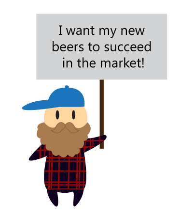

- For the great flavor?
- To experience something new?
- Because they know & trust your brand?

## Only one of these answers leads to a sustainable brewing business

## Will they continue buying your beers for their great flavor?

No.

Consumer preference is not consistent. Consumer preference changes with:

- Season
- Past experience
- Food choice
- A desire for novelty
- Availability
- Relying on the sales of one beer, for all consumers, all the time, is a recipe for disaster.

## Will they continue buying your beers to try something new?

Maybe.

Everyone has a drive for novelty and excitement - but there's no guarantee they will choose your beer.

Relying on a series of one-off "novelty" beers is a short term band-aid for sales and marketing. It's not a repeatable or predictable process for growing your brand.

[figure not shown]

## Will they continue buying your beers because they know & trust your brand?

Yes.

## Your brand is valuable. Protect it.

## Quality control is your brand's shield

Quality control isn't an insurance policy. It's step 0 in successfully building your brand over the next 30 years.

Every interaction you have with a consumer is a chance to turn them into a brand loyalist and keep them as a consumer.

## Consistently producing consistently high quality beers is the only recipe for success

## Craft beer brewers build their brand through consumer loyalty

The average craft beer consumer drinks approximately 32 gallons of beer per year.

- Assuming an average of:
  - ~$300 per barrel of beer
  - ~8% brewery profit margin (aggregate)

Each consumer is drinking about one barrel of beer per year - worth an average of ~$300 revenue, and $24 profit.

It takes a lot of customers to build a large beer brand.

## $24 in profit doesn't sound like a lot, but the best brands in the industry have kept consumers loyal for over 30 years - while also growing their average price and profit margin with scale.

That means each consumer is worth ~$10,000 in revenue over their lifetime.

Invest in quality control. Your beer is worth it.

## You build consumer loyalty through communication and consistency

We believe that flavor-profile consistency is the key to building consumer loyalty and the basis of any competitive beer product.

The products you sell make up your brand. Each product needs to reaffirm your brand's quality and consistency to every consumer.

## You build consistency through quality control

Quality control means checking each batch for:

- Flaws, taints, and contaminations
- Batch-to-batch deviations
- Decreased shelf life and accelerated degradation
- Diffrences between cans, bottles, and kegs

## Consistent products are the foundation for sales and marketing

Consistently high quality products build:

- Brand loyalists & repeat purchases
- A following & better word of mouth
- Your average price point
- Your profit margin

## Learn More

### [Take the free quality control email course!](https://gastrograph.com/resources/courses/qc-course-step-1.html)

One 15 minute email per week to start a quality control program at your company.  
1) This week: Setting a quality control goal 2) Choose your test  
3) Select your panelists  
4) Synchronize your production and review schedule  
5) Train your panelists  
6) Generate enough data to make decisions  
7) Analyze the results  
8) Apply your findings to your production and distribution process  
9) Repeat steps 1-8 for every batch of every product

10) Succeed